# Assignment 3 Task 3 - Santa Barbara LTER Urchins

### Section 2: Purple urchins (by site and year)

In this Section, the purple urchin data will be explored by site and year. In this code chunk, the data are filtered for purple urchins, date is converted to class “Date”, and new columns are added.

```r
# creates the new dataframe beginning with urchin_data
purple_urchins <- urchin_data %>%
  filter(common_name == "Purple Urchin") %>% # filters only purple rows

# updates the date column to be Date format and adds a year column
  mutate(date = mdy(date)) %>%
  mutate(year = year(date)) %>%

# adds a new column called "site_full" that includes the full site names
  mutate(site_full = case_when(
    site == "NAPL" ~ "Naples Reef",
    site == "AQUE" ~ "Arroyo Quemado Reef",
    site == "CARP" ~ "Carpinteria Reef",
    site == "MOHK" ~ "Mohawk Reef",
    site == "IVEE" ~ "Isla Vista Reef"
  ))
```

This code stores a table (`purple_urchin_summary`) containing the total number of purple urchins observed by site and year (not a final formatted table).

```r
purple_urchin_summary <- purple_urchins %>%
  count(site_full, year)
```

#### Visualizing the data

This step visualizes the data through a final graph showing counts of purple urchins recorded at each site over time for the years included in the study.

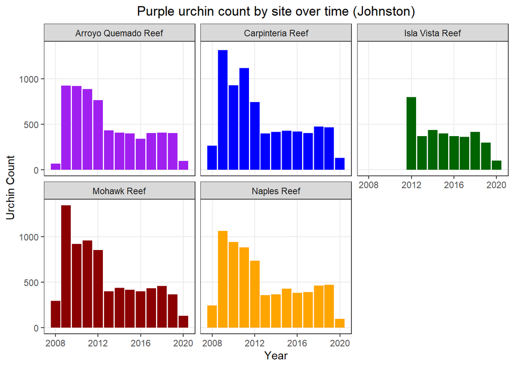

Figure 2. Purple urchin counts by site in Santa Barbara, 2008-2020 (data: SBC LTER)

```r
# creates a bar graph (column geometry) using purple_urchin_summary dataframe and fills the color by site name
ggplot(data = purple_urchin_summary, aes(x = year, y = n, fill = site_full)) +
  geom_col() +

# updates the axes/title names
  labs(x = "Year", y = "Urchin Count",
       title = "Purple urchin count by site over time (Johnston)") +

# wraps by site (splits the graph)
  facet_wrap(~ site_full) +
  theme_bw() + # cleaner theme
  theme(plot.title = element_text(hjust = 0.5), # centers title
        panel.grid.minor = element_blank() # removes major gridlines
        ) +

# changes fill colors to be more aesthetic
  scale_fill_manual(values = c("purple", "blue",
                               "dark green", "dark red", "orange")) +

# removes unnecessary legend
  guides(fill = FALSE)
```

#### End of Assignment 3 Task 3